# 🦇 From Gradient Descent to Gradient Boosting

Loss functions, two ways to minimize them, AdaBoost and beyond

Son Nguyen

## What you will learn

1. **Gradient descent** on simple quadratics (1-D and 2-D), with the first steps computed by hand
2. **Loss functions** and why training a model means minimizing one
3. **Two ways** to minimize a loss: gradient on the **parameters** (regression, neural networks) or on the **predictions** (gradient boosting)
4. **Squared loss vs exponential loss (AdaBoost)**, step by step
5. **More losses** for gradient boosting, with use cases

# 🕷️ Part 1: Gradient descent

## What is gradient descent?

**Goal:** find the input $\theta$ that makes a function $f(\theta)$ as **small** as possible.

- The **gradient** $f'(\theta)$ is the slope: it points **uphill**
- So walk the other way. Repeat:

$$\boxed{\;\theta_{k+1}=\theta_k-\eta\,f'(\theta_k)\;}\qquad \eta>0\ \text{is the step size (learning rate)}$$

- Steep slope: big step. Flat slope: small step. At the minimum the slope is 0, so we stop moving
- It works for **any** differentiable $f$, not just for squared errors. We start with the simplest case, a **quadratic**

## Example 1 (one dimension): $f(\theta)=(\theta-3)^2$

The minimum is at $\theta=3$. The slope is $f'(\theta)=2(\theta-3)$. Start at $\theta_0=0$ with $\eta=0.2$.

| step k | θ_k | slope f′(θ_k) = 2(θ_k − 3) | θ_(k+1) = θ_k − 0.2·slope | f(θ_k) |
| --- | --- | --- | --- | --- |
| 0 | 0.0000 | -6.0000 | 1.2000 | 9.0000 |
| 1 | 1.2000 | -3.6000 | 1.9200 | 3.2400 |
| 2 | 1.9200 | -2.1600 | 2.3520 | 1.1664 |
| 3 | 2.3520 | -1.2960 | 2.6112 | 0.4199 |
| 4 | 2.6112 | -0.7776 | 2.7667 | 0.1512 |
| 5 | 2.7667 | -0.4666 | 2.8600 | 0.0544 |

**By hand, step 1:** slope at 0 is $2(0-3)=-6$, so $\theta_1=0-0.2\cdot(-6)=1.2$. **Step 2:** slope $=2(1.2-3)=-3.6$, so $\theta_2=1.2+0.72=1.92$.

## Example 1: the steps approach the minimum

Each step multiplies the distance to the minimum by $1-2\eta=0.6$: the error is $3,\;1.8,\;1.08,\;0.648,\dots$

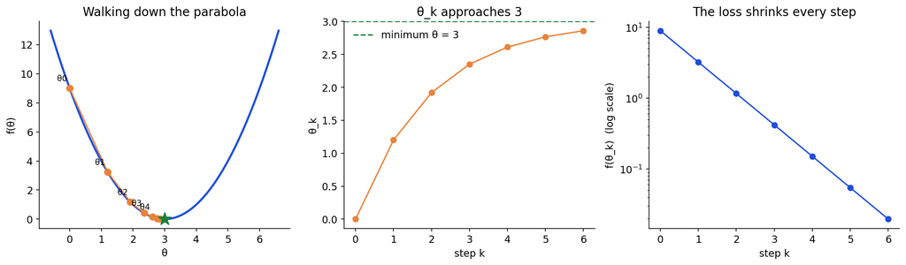

## Why does it work? A straight-line approximation

Near $\theta_k$ the curve looks like its **tangent line**: $\;f(\theta_k+\delta)\approx f(\theta_k)+f'(\theta_k)\,\delta$. The line goes down to the right if the slope is negative, so we move **right**.

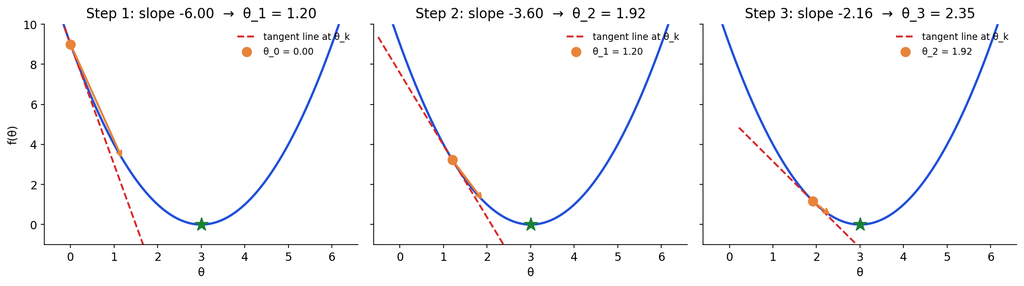

## The step size $\eta$ matters

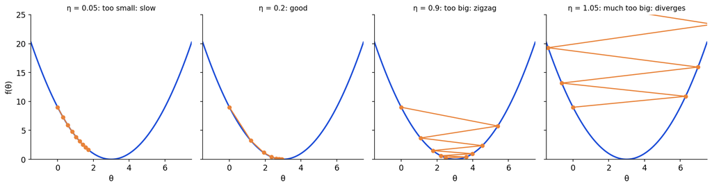

- For this quadratic the update is $\theta_{k+1}-3=(1-2\eta)(\theta_k-3)$. It converges when $|1-2\eta|<1$, that is $0<\eta<1$
- In practice $\eta$ is a **tuning knob**: the same one that appears later as the learning rate $\nu$ of gradient boosting

## Example 2 (two dimensions): $f(\theta_1,\theta_2)=(\theta_1-3)^2+2(\theta_2-2)^2$

Minimum at $(3,2)$. The **gradient** is the vector of slopes $\nabla f=\big(2(\theta_1-3),\;4(\theta_2-2)\big)$. Update: $\;\boldsymbol\theta\leftarrow\boldsymbol\theta-\eta\,\nabla f$. Start $(0,0)$, $\eta=0.2$.

| k | θ₁ | θ₂ | ∂f/∂θ₁ | ∂f/∂θ₂ | θ₁ new = θ₁ − 0.2·∂f/∂θ₁ | θ₂ new = θ₂ − 0.2·∂f/∂θ₂ | f |
| --- | --- | --- | --- | --- | --- | --- | --- |
| 0 | 0.000 | 0.000 | -6.000 | -8.000 | 1.200 | 1.600 | 17.000 |
| 1 | 1.200 | 1.600 | -3.600 | -1.600 | 1.920 | 1.920 | 3.560 |
| 2 | 1.920 | 1.920 | -2.160 | -0.320 | 2.352 | 1.984 | 1.179 |
| 3 | 2.352 | 1.984 | -1.296 | -0.064 | 2.611 | 1.997 | 0.420 |

**By hand, step 1:** $\nabla f(0,0)=(2(0-3),\,4(0-2))=(-6,-8)$, so $\boldsymbol\theta_1=(0,0)-0.2(-6,-8)=(1.2,\,1.6)$.

## Example 2: the path to the minimum

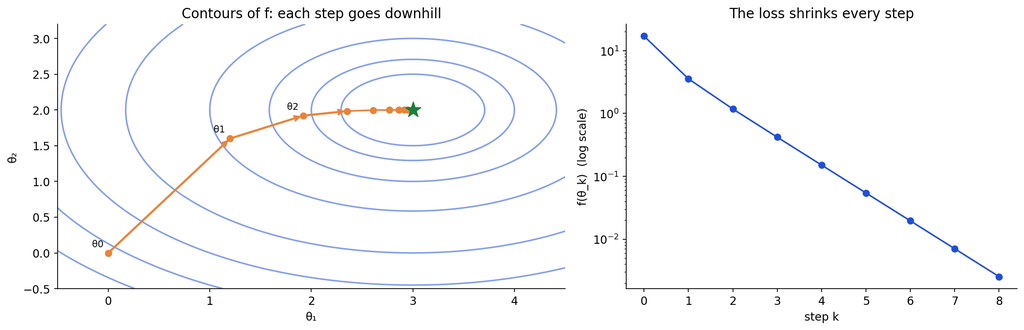

The valley is steeper in $\theta_2$ than in $\theta_1$, so $\theta_2$ settles faster. After 8 steps the distance to the minimum is $|\theta_1-3|=0.050$ and $|\theta_2-2|=0.000005$.

## Picture: a ball rolling downhill

[figure not shown]

- Think of the loss as a **landscape** and the parameters as the position of a ball. Gradient descent lets the ball roll **downhill**, step by step, toward a valley (a minimum)
- Our quadratics have **one** valley. Real loss surfaces, like this one, can have **several**: where the ball ends up can depend on where it starts

## Gradient descent in one box

**1. Pick a start**  
$\boldsymbol\theta_0$

→

**2. Compute the gradient**  
$\nabla f(\boldsymbol\theta_k)$

→

**3. Step downhill**  
$\boldsymbol\theta_{k+1}=\boldsymbol\theta_k-\eta\nabla f$

↺

The function $f$ can be **anything differentiable**. In machine learning, $f$ is the **loss** and $\boldsymbol\theta$ is what we are allowed to change. The next part shows what that means.

# 🕷️ Part 2: Loss functions in model training

## Training a model = minimizing a loss

- A model makes **predictions** $\hat y_i$ for the training data. The **loss** adds up how wrong they are: $L=\sum_i \ell(y_i,\hat y_i)$
- Small loss = good predictions. The training algorithm’s job: **find the parameters that minimize the loss**
- Different problems and different worries (outliers, probabilities, …) call for different loss functions $\ell$

**Training = gradient descent on a loss.** Part 1 told us how to minimize any function. What remains is to say *what is being changed* and *which loss*.

## Example: a linear model on 4 points

The data (we will use it again later):

| x | y |
| --- | --- |
| 1 | 2 |
| 2 | 3 |
| 3 | 5 |
| 4 | 4 |

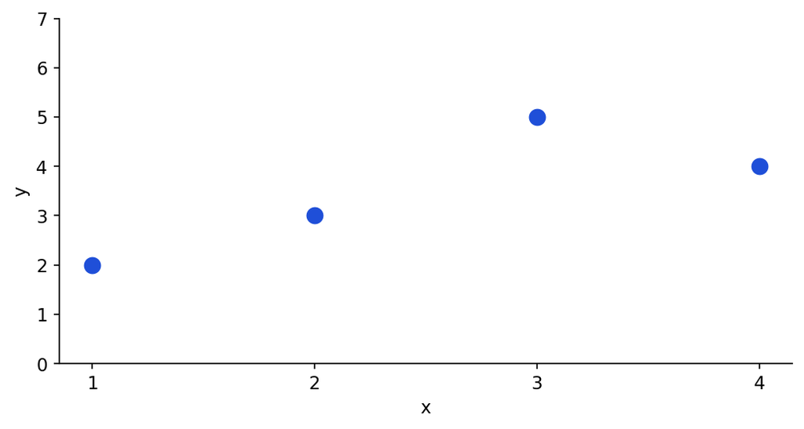

Model: $\hat y=\theta_0+\theta_1x$ with parameters $\boldsymbol\theta=(\theta_0,\theta_1)$. Different $\boldsymbol\theta$ give different lines, and so different predictions $\hat y_i$. Next: how good is a line?

## Building the squared loss, column by column

Start with the data. Each click adds one column; the earlier columns stay in place.

| $x$ | $y$ | predicted $\hat y=\theta_0+\theta_1x$ | squared loss $\tfrac12(y-\hat y)^2$ |
| --- | --- | --- | --- |
| 1 | 2 | $\theta_0+\theta_1$ | $\tfrac12(2-\theta_0-\theta_1)^2$ |
| 2 | 3 | $\theta_0+2\theta_1$ | $\tfrac12(3-\theta_0-2\theta_1)^2$ |
| 3 | 5 | $\theta_0+3\theta_1$ | $\tfrac12(5-\theta_0-3\theta_1)^2$ |
| 4 | 4 | $\theta_0+4\theta_1$ | $\tfrac12(4-\theta_0-4\theta_1)^2$ |

Total loss = the four entries added up:

$$\begin{aligned}L(\theta_0,\theta_1)&=\tfrac12(2-\theta_0-\theta_1)^2+\tfrac12(3-\theta_0-2\theta_1)^2\\&\quad+\tfrac12(5-\theta_0-3\theta_1)^2+\tfrac12(4-\theta_0-4\theta_1)^2\end{aligned}$$

## Building the absolute loss, column by column

Same table, new loss: $\ell(y,\hat y)=\lvert y-\hat y\rvert$.

| $x$ | $y$ | predicted $\hat y=\theta_0+\theta_1x$ | absolute loss $\lvert y-\hat y\rvert$ |
| --- | --- | --- | --- |
| 1 | 2 | $\theta_0+\theta_1$ | $\lvert 2-\theta_0-\theta_1\rvert$ |
| 2 | 3 | $\theta_0+2\theta_1$ | $\lvert 3-\theta_0-2\theta_1\rvert$ |
| 3 | 5 | $\theta_0+3\theta_1$ | $\lvert 5-\theta_0-3\theta_1\rvert$ |
| 4 | 4 | $\theta_0+4\theta_1$ | $\lvert 4-\theta_0-4\theta_1\rvert$ |

Total loss = the four entries added up:

$$\begin{aligned}L(\theta_0,\theta_1)&=\lvert 2-\theta_0-\theta_1\rvert+\lvert 3-\theta_0-2\theta_1\rvert\\&\quad+\lvert 5-\theta_0-3\theta_1\rvert+\lvert 4-\theta_0-4\theta_1\rvert\end{aligned}$$

## Building the Huber loss, column by column

$\ell_\delta(r)=\tfrac12r^2$ if $|r|\le\delta$, else $\delta(|r|-\tfrac12\delta)$, with $r=y-\hat y$.

| $x$ | $y$ | predicted $\hat y=\theta_0+\theta_1x$ | Huber loss $\ell_\delta(y-\hat y)$ |
| --- | --- | --- | --- |
| 1 | 2 | $\theta_0+\theta_1$ | $\ell_\delta(2-\theta_0-\theta_1)$ |
| 2 | 3 | $\theta_0+2\theta_1$ | $\ell_\delta(3-\theta_0-2\theta_1)$ |
| 3 | 5 | $\theta_0+3\theta_1$ | $\ell_\delta(5-\theta_0-3\theta_1)$ |
| 4 | 4 | $\theta_0+4\theta_1$ | $\ell_\delta(4-\theta_0-4\theta_1)$ |

Total loss = the four entries added up:

$$\begin{aligned}L(\theta_0,\theta_1)&=\ell_\delta(2-\theta_0-\theta_1)+\ell_\delta(3-\theta_0-2\theta_1)\\&\quad+\ell_\delta(5-\theta_0-3\theta_1)+\ell_\delta(4-\theta_0-4\theta_1)\end{aligned}$$

## Building the quantile loss, column by column

$\rho_\tau(r)=\tau r$ if $r\ge0$, else $(\tau-1)r$, with $r=y-\hat y$.

| $x$ | $y$ | predicted $\hat y=\theta_0+\theta_1x$ | quantile loss $\rho_\tau(y-\hat y)$ |
| --- | --- | --- | --- |
| 1 | 2 | $\theta_0+\theta_1$ | $\rho_\tau(2-\theta_0-\theta_1)$ |
| 2 | 3 | $\theta_0+2\theta_1$ | $\rho_\tau(3-\theta_0-2\theta_1)$ |
| 3 | 5 | $\theta_0+3\theta_1$ | $\rho_\tau(5-\theta_0-3\theta_1)$ |
| 4 | 4 | $\theta_0+4\theta_1$ | $\rho_\tau(4-\theta_0-4\theta_1)$ |

Total loss = the four entries added up:

$$\begin{aligned}L(\theta_0,\theta_1)&=\rho_\tau(2-\theta_0-\theta_1)+\rho_\tau(3-\theta_0-2\theta_1)\\&\quad+\rho_\tau(5-\theta_0-3\theta_1)+\rho_\tau(4-\theta_0-4\theta_1)\end{aligned}$$

## Loss functions at a glance

| Loss | Formula for one point | Good for |
| --- | --- | --- |
| Squared | $\tfrac12(y-\hat y)^2$ | regression, the default (estimates the mean) |
| Absolute | $\lvert y-\hat y\rvert$ | regression with outliers (estimates the median) |
| Huber | squared if $\lvert r\rvert\le\delta$, else linear | regression, small errors count fully, big ones are capped |
| Quantile $\tau$ | $\tau r$ if $r\ge0$, else $(\tau-1)r$ | predicting a high or low quantile |
| Logistic | $-[y\ln p+(1-y)\ln(1-p)]$ | classification with probabilities |
| Exponential | $e^{-yF}$ | classification, **AdaBoost** |

Whatever the loss, the task is the same: **choose the model’s parameters (or predictions) to make the total loss as small as possible.**

# 🕷️ Part 3: Two ways to minimize a loss

## The two approaches

The loss $L=\sum_i\ell(y_i,\hat y_i)$ depends on the predictions $\hat y_i$, and the predictions depend on the model. So there are two natural places to take the gradient:

**Approach 1: gradient on the parameters**

$$\boldsymbol\theta\leftarrow\boldsymbol\theta-\eta\,\frac{\partial L}{\partial\boldsymbol\theta}$$

The model has a **fixed form** with parameters $\boldsymbol\theta$.

**How the negative gradient is used:** it tells us how to **improve the parameters** for the next round.

**Approach 2: gradient on the predictions**

$$\hat y_i\leftarrow\hat y_i-\eta\,\frac{\partial L}{\partial\hat y_i}$$

Treat each prediction as the unknown, then **build a model that follows the step**.

**How the negative gradient is used:** it is the **next target**: the new model is fit to it.

In **both** approaches the loss goes **down after every step (round)**, and we keep heading toward the minimum.

**Examples.** Approach 1: linear regression, logistic regression, **neural networks**. Approach 2: **gradient boosting**.

## The same 4 points, the same loss

| x | y |
| --- | --- |
| 1 | 2 |
| 2 | 3 |
| 3 | 5 |
| 4 | 4 |

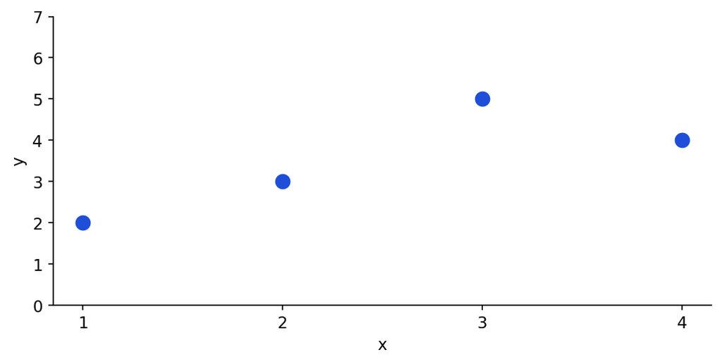

Squared loss in terms of the **predictions** $\hat y_1,\dots,\hat y_4$:

$$L=\tfrac12\Big[(2-\hat y_1)^2+(3-\hat y_2)^2+(5-\hat y_3)^2+(4-\hat y_4)^2\Big]$$

For the **linear model** $\hat y_i=\theta_0+\theta_1x_i$ the same loss in terms of the **parameters**:

$$L(\theta_0,\theta_1)=\tfrac12\Big[(2-\theta_0-\theta_1)^2+(3-\theta_0-2\theta_1)^2+(5-\theta_0-3\theta_1)^2+(4-\theta_0-4\theta_1)^2\Big]$$

## Step 1, written out: side by side

**Approach 1: gradient on the parameters**

Form of the loss, before taking the gradient:

$$\begin{aligned}L(\theta_0,\theta_1)=\tfrac12\Big[&(2-\theta_0-\theta_1)^2+(3-\theta_0-2\theta_1)^2\\&+(5-\theta_0-3\theta_1)^2+(4-\theta_0-4\theta_1)^2\Big]\end{aligned}$$

Differentiate $L(\theta_0,\theta_1)$ with respect to $\theta_0$ and $\theta_1$:

$$\begin{aligned}\frac{\partial L}{\partial\theta_0}=-\Big[&(2-\theta_0-\theta_1)+(3-\theta_0-2\theta_1)\\&+(5-\theta_0-3\theta_1)+(4-\theta_0-4\theta_1)\Big]\end{aligned}$$

$$\begin{aligned}\frac{\partial L}{\partial\theta_1}=-\Big[&1(2-\theta_0-\theta_1)+2(3-\theta_0-2\theta_1)\\&+3(5-\theta_0-3\theta_1)+4(4-\theta_0-4\theta_1)\Big]\end{aligned}$$

**Approach 2: gradient on the predictions**

Form of the loss, before taking the gradient:

$$\begin{aligned}L(\hat y_1,\dots,\hat y_4)=\tfrac12\Big[&(2-\hat y_1)^2+(3-\hat y_2)^2\\&+(5-\hat y_3)^2+(4-\hat y_4)^2\Big]\end{aligned}$$

Differentiate $L(\hat y_1,\dots,\hat y_4)$ with respect to each prediction:

$$\begin{aligned}\frac{\partial L}{\partial\hat y_1}&=-(2-\hat y_1)\\\frac{\partial L}{\partial\hat y_2}&=-(3-\hat y_2)\\\frac{\partial L}{\partial\hat y_3}&=-(5-\hat y_3)\\\frac{\partial L}{\partial\hat y_4}&=-(4-\hat y_4)\end{aligned}$$

These are minus the residuals: the **next targets**.

## The two approaches side by side

|  | **Approach 1: gradient on parameters** | **Approach 2: gradient on predictions** |
| --- | --- | --- |
| What changes | parameters $\boldsymbol\theta$ | the prediction function $F(x)$ |
| Gradient | $\partial L/\partial\boldsymbol\theta$ (chain rule) | $\partial L/\partial F_i$ (no chain rule needed) |
| Update | $\boldsymbol\theta\leftarrow\boldsymbol\theta-\eta\,\partial L/\partial\boldsymbol\theta$ | $F\leftarrow F+\nu\,h$, where $h$ is fit to $-\partial L/\partial F$ |
| Model form | fixed (line, network, …) | grows: one new tree per round |
| Examples | linear / logistic regression, neural networks | **gradient boosting**, AdaBoost |
| Needs | a loss differentiable in $\boldsymbol\theta$ | a loss differentiable in $\hat y$ (trees need not be) |

Approach 1 uses $\dfrac{\partial\ell}{\partial\hat y}\cdot\dfrac{\partial\hat y}{\partial\theta}$. Gradient boosting keeps **only the first factor** and replaces the second by “fit a tree to it”. That is why the pseudo-residual $-\partial\ell/\partial\hat y$ is the heart of boosting.

# 🕷️ Part 4: Squared loss vs exponential loss (AdaBoost)

## Same data, two loss functions

Both models are gradient boosting with stumps. Only the **loss** differs. Eight points, class labels $y=\pm1$:

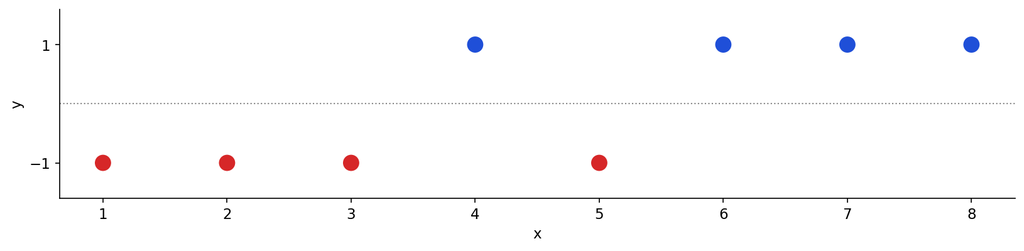

- **Squared loss** $\tfrac12(y-F)^2$ treats the labels as numbers (a regression on $\pm1$); classify by $\operatorname{sign}(F)$
- **Exponential loss** $e^{-yF}$ is AdaBoost’s loss; classify by $\operatorname{sign}(F)$

## The steps, side by side

| Step | **Squared loss** | **Exponential loss (AdaBoost)** |
| --- | --- | --- |
| Loss $\ell(y,F)$ | $\tfrac12(y-F)^2$ | $e^{-yF}$ |
| 0. Start $F_0$ | mean of $y$ | $\tfrac12\ln\frac{\#(+1)}{\#(-1)}$ (here 0) |
| 1. Pseudo-residual $-\partial\ell/\partial F$ | $y-F$ (the residual) | $y\,e^{-yF}$ = label × weight |
| 2. Weak learner | stump fit to $r$ by least squares | stump $h\in\{-1,+1\}$ with the smallest **weighted error** $\varepsilon$ |
| 3. Leaf value / step size | leaf = mean of $r$ in the leaf; fixed learning rate $\nu$ | $\alpha=\tfrac12\ln\frac{1-\varepsilon}{\varepsilon}$ (exact line search) |
| 4. Update | $F\leftarrow F+\nu\,h$ | $F\leftarrow F+\alpha\,h$ |
| 5. Prediction | $\operatorname{sign}(F)$ | $\operatorname{sign}(F)$ |

## Squared vs exponential: what is different in practice?

|  | Squared loss | Exponential loss (AdaBoost) |
| --- | --- | --- |
| Punishes a wrong point | quadratically in the error | **exponentially** in the margin |
| A mislabeled point | pulls with strength $\propto$ its error | pulls with strength $e^{-yF}$: grows without bound |
| Natural task | regression (numbers) | two-class classification |
| Step size | small fixed $\nu$ | exact line search $\alpha$ |
| Output | number, or sign for classes | score, class $=$ sign |

| margin y·F | squared \|gradient\| = \|y − F\| = \|1 − m\| | exponential \|gradient\| = e^(−m) |
| --- | --- | --- |
| -3.0 | 4.0 | 20.09 |
| -2.0 | 3.0 | 7.39 |
| -1.0 | 2.0 | 2.72 |
| 0.0 | 1.0 | 1.00 |
| 1.0 | 0.0 | 0.37 |
| 2.0 | 1.0 | 0.14 |

- For a badly wrong point (margin $-3$) the exponential gradient is $\approx 20$ versus $4$: **AdaBoost is more sensitive to label noise**

# 🕷️ Part 5: More loss functions for gradient boosting

## The same recipe, different losses

| Step | **Squared** | **Absolute** | **Huber** | **Quantile** | **Logistic** | Exponential (**AdaBoost**) | **Poisson** |
| --- | --- | --- | --- | --- | --- | --- | --- |
| Loss $\ell(y,F)$ | $\tfrac12(y-F)^2$ | $\lvert y-F\rvert$ | $\tfrac12r^2$ if $\lvert r\rvert\le\delta$, else $\delta(\lvert r\rvert-\tfrac12\delta)$ | $\tau r$ if $r\ge0$, else $(\tau-1)r$, with $r=y-F$ | $-[y\ln p+(1-y)\ln(1-p)]$, $p=\frac{1}{1+e^{-F}}$, $y\in\{0,1\}$ | $e^{-yF}$, $y\in\{-1,+1\}$ | $e^{F}-yF$, $y=0,1,2,\dots$ |
| 0. Start $F_0$ | mean of $y$ | median of $y$ | median of $y$ | $\tau$-quantile of $y$ | $\ln\frac{\bar y}{1-\bar y}$ (log-odds) | $\tfrac12\ln\frac{\#(+1)}{\#(-1)}$ | $\ln\bar y$ |
| 1. Pseudo-residual $-\partial\ell/\partial F$ | $y-F$ (the residual) | $\operatorname{sign}(y-F)$ ($\pm1$) | $r$ clipped to $[-\delta,\delta]$ | $\tau$ if $y>F$, else $\tau-1$ | $y-p$ | $y\,e^{-yF}$ = label × weight | $y-e^{F}$ |
| 2. Weak learner | stump fit to $r$ by least squares | stump fit to $r$ by least squares | stump fit to the clipped $r$ | stump fit to $r$ by least squares | stump fit to $r$ by least squares | stump $h\in\{-1,+1\}$ with the smallest weighted error $\varepsilon$ | stump fit to $r$ by least squares |
| 3. Leaf value / step size | leaf = mean of $r$ in the leaf; fixed learning rate $\nu$ | leaf = **median** of the residuals in the leaf; fixed $\nu$ | leaf = median of $r$ + mean of the clipped deviations; fixed $\nu$ | leaf = $\tau$-quantile of the residuals in the leaf; fixed $\nu$ | leaf $=\sum r\,/\sum p(1-p)$ (Newton step); fixed $\nu$ | $\alpha=\tfrac12\ln\frac{1-\varepsilon}{\varepsilon}$ (exact line search) | leaf $=\sum r\,/\sum e^{F}$ (Newton step); fixed $\nu$ |
| 4. Update | $F\leftarrow F+\nu\,h$ | $F\leftarrow F+\nu\,h$ | $F\leftarrow F+\nu\,h$ | $F\leftarrow F+\nu\,h$ | $F\leftarrow F+\nu\,h$ | $F\leftarrow F+\alpha\,h$ | $F\leftarrow F+\nu\,h$ |
| 5. Prediction | $F$ (a number) | $F$ (estimates the median) | $F$ (a number) | $F$ (estimates the $\tau$-quantile) | $p=\sigma(F)$; class 1 if $p>0.5$ | $\operatorname{sign}(F)$ | $e^{F}>0$ (expected count) |

## Which loss for which problem?

| Problem | Loss | Why |
| --- | --- | --- |
| Regression, clean data | squared | smooth, standard, estimates the mean |
| Regression with outliers | absolute / Huber | outliers cannot dominate |
| Predict a range or a safe value | quantile | estimates a chosen quantile |
| Counts, non-negative amounts | Poisson (Gamma, Tweedie) | respects the data’s scale |
| Two classes, need probabilities | logistic | calibrated probabilities |
| Two classes, classic boosting | exponential (AdaBoost) | simple weights; sensitive to label noise |
| Many classes | softmax | one score per class |

# 🕷️ Wrap-up

## Summary

- **Gradient descent** minimizes any differentiable function by stepping against the slope, $\theta\leftarrow\theta-\eta f'(\theta)$
- **Training a model** means choosing parameters (or predictions) that minimize a **loss**
- **Approach 1:** gradient on the **parameters** (linear and logistic regression, neural networks). **Approach 2:** gradient on the **predictions**, then fit a tree to follow it (**gradient boosting**)
- For squared loss the negative gradient on the predictions is the **residual**. **AdaBoost** is the same recipe with the exponential loss
- Other losses (absolute, Huber, quantile, logistic, Poisson, softmax) only change the **start, pseudo-residual and leaf value**
- Pick the loss for the problem: it defines what the model learns

# Thank you!

Gradient descent and gradient boosting